# Using R for Analysis

# Jake Tolbert

### Director of Data Services

### Alumni & Development

# R & R Studio

- R - programming language with a focus on statistical analysis
- R Studio - an IDE for R

# Tool Comparison

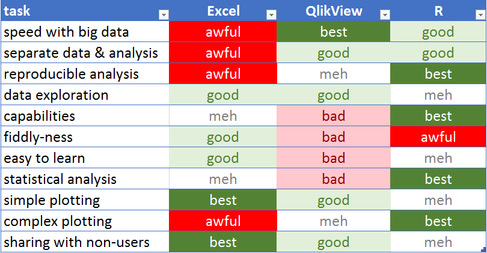

# Complex Mailing Lists

Use R (or SQL or SAS or some such).

- Data can change underneath, but criteria can be saved.
- QV has no way to do complex filtering eg:
  - T&D majors around Decatur OR $1000 lifetime gifts to T&D Building

# Pulling A List

```r
# imagine I'm connected to a database with databases:
#   - majors_tbl with pidm, major
#   - regions_tbl with pidm, region
#   - donors_tbl with pidm, td_gifts, athletics_gifts, uc_gifts, scholarship_gifts
#   - demographic_tbl with pidm, mailing address, and more ...


# get a list of all Theatre & Dance majors
tdmajors  <- majors_tbl %>%
  filter( major == 'TD'  )

# get a list of everybody around Decatur
arounddecatur  <- regions_tbl %>%
  filter( region == 'DECATUR' )

# get T&D majors around Decatur
td_around_decatur  <- tdmajors %>%
  semi_join(arounddecatur, by = 'pidm') %>%
  distinct(pidm)
```

# Pulling A List (cont.)

```r
# get donors who've given $1000+ to Theatre & Dance building
td_donors  <- donors_tbl %>%
  filter(td_gifts  >= 1000 ) %>%
  distinct(pidm)

#combine both lists then add mailing data
my_mailing  <- bind_rows( td_around_decatur, td_donors) %>%
  left_join(
    demographic_tbl %>%
        select(pidm, name, address, city, st, zip)
      , by = 'pidm', copy = T
  ) %>%
  collect()
```

# Exploratory Analysis

- Use QV
  - load data
  - set up list boxes and charts
  - click around
- Use Excel
  - click around
  - run some pivot tables
- R requirees a mental model
  - use summary stats, environment pane
  - `View(airlinedata)`

# Statisical Analysis

Use R for complex statistical analysis.

# Quick Summary Data

```r
summary(airlinedata$DEP_DELAY)
```

```
##    Min. 1st Qu.  Median    Mean 3rd Qu.    Max.    NA's
## -151.00   -5.00   -1.00   11.55    9.00 1341.00    5135
```

# Quick Summary Data

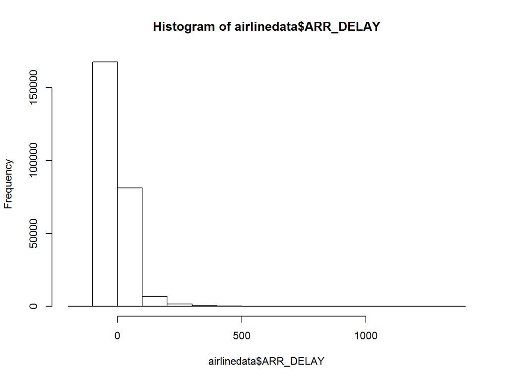

```r
hist(airlinedata$ARR_DELAY)
```

# Quick Summary Data

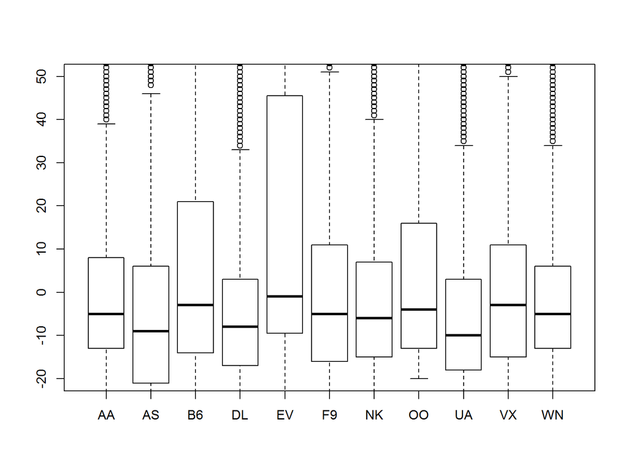

```r
boxplot(airlinedata$ARR_DELAY ~ airlinedata$UNIQUE_CARRIER, ylim = c(-20,50))
```

# More Complex Analytical Tasks

```r
cor.test(hour(airlinedata$DepTime), airlinedata$ARR_DELAY)
```

```
##
##  Pearson's product-moment correlation
##
## data:  hour(airlinedata$DepTime) and airlinedata$ARR_DELAY
## t = 74.108, df = 258120, p-value < 2.2e-16
## alternative hypothesis: true correlation is not equal to 0
## 95 percent confidence interval:
##  0.1405595 0.1481144
## sample estimates:
##       cor
## 0.1443391
```

# More Complex Analytical Tasks

```r
t.test(
    airlinedata %>% filter(ORIGIN == 'ORD') %>% pluck('ARR_DELAY')
  , airlinedata %>% filter(ORIGIN == 'CLT') %>% pluck('ARR_DELAY')
)
```

```
##
##  Welch Two Sample t-test
##
## data:  airlinedata %>% filter(ORIGIN == "ORD") %>% pluck("ARR_DELAY") and airlinedata %>% filter(ORIGIN == "CLT") %>% pluck("ARR_DELAY")
## t = -6.0808, df = 7862.8, p-value = 1.252e-09
## alternative hypothesis: true difference in means is not equal to 0
## 95 percent confidence interval:
##  -6.674303 -3.420147
## sample estimates:
## mean of x mean of y
##  1.953069  7.000294
```

# Creating a Report for Others

1. Build with R Markdown
   - integrate Markdown + R into generated html/pdf.
2. Use QV for dashboards, etc.
3. Dump to Excel and format

# Building Statistical Models

```r
lm_model <- lm(ARR_DELAY ~ DAY_OF_WEEK + DEP_DELAY, data = mydata)

rf_model <- randomForest(
                 x = mydata %>% select(DAY_OF_WEEK , UNIQUE_CARRIER)
               , y = mydata$ARR_DELAY
             )

caret_model <- train(
                x = mydata %>% select(DAY_OF_WEEK , UNIQUE_CARRIER)
              , y = mydata$ARR_DELAY
              , trControl = trainControl(number = 3)
              )
```

# Linear Model

```r
 tidy(lm_model)
```

```
## # A tibble: 3 x 5
##   term        estimate std.error statistic  p.value
##   <chr>          <dbl>     <dbl>     <dbl>    <dbl>
## 1 (Intercept)  -5.83     0.428     -13.6   1.80e-41
## 2 DAY_OF_WEEK  -0.0470   0.0943     -0.499 6.18e- 1
## 3 DEP_DELAY     1.02     0.00480   212.    0.
```

# Random Forest Model

```r
print(rf_model)
```

```
##
## Call:
##  randomForest(x = mydata %>% select(DAY_OF_WEEK, UNIQUE_CARRIER),      y = mydata$ARR_DELAY)
##                Type of random forest: regression
##                      Number of trees: 500
## No. of variables tried at each split: 1
##
##           Mean of squared residuals: 1732.185
##                     % Var explained: 0.81
```

# Caret Model

```r
print(caret_model)
```

```
## Random Forest
##
## 5000 samples
##    2 predictor
##
## No pre-processing
## Resampling: Bootstrapped (3 reps)
## Summary of sample sizes: 5000, 5000, 5000
## Resampling results:
##
##   RMSE    Rsquared     MAE
##   42.499  0.006168087  24.07448
##
## Tuning parameter 'mtry' was held constant at a value of 2
```

# Build New Data to Predict New Cases

```r
newdata  <- data_frame(
    DAY_OF_WEEK      = c(1L,2L,3L,4L,5L)
  , UNIQUE_CARRIER  = factor(
                        c("AA", "AS", "EV", "WN", "OO")
                      , levels = levels(mydata$UNIQUE_CARRIER)
                    )
)

newdata
```

```
## # A tibble: 5 x 2
##   DAY_OF_WEEK UNIQUE_CARRIER
##         <int> <fct>
## 1           1 AA
## 2           2 AS
## 3           3 EV
## 4           4 WN
## 5           5 OO
```

# Predict New Cases

```r
predictions  <- predict(caret_model, newdata)
newdata$predictedDelay  <- predictions
newdata
```

```
## # A tibble: 5 x 3
##   DAY_OF_WEEK UNIQUE_CARRIER predictedDelay
##         <int> <fct>                   <dbl>
## 1           1 AA                       2.23
## 2           2 AS                      -6.77
## 3           3 EV                       3.23
## 4           4 WN                       5.86
## 5           5 OO                       4.52
```

# Use the Tidyverse

- a series of packages creating a new grammar for R

[figure not shown]

# Load Packages in Every Script

My scripts almost always begin like this:

```r
# libraries -------------------------------------------

library(tidyverse)
library(magrittr)
library(lubridate)
library(readxl)

# actual real work ------------------------------------------------

# start doing something here....
```

# Base R - Use Nested Functions

```r
fullstory  <- bop(
  scoop(
    hop(foo_foo, through = forest),
    up = field_mice
  ),
  on = head
)
```

- really hard to read
- nobody thinks this way (so it’s hard to write this way)

# Lots of Little Steps, Saving New Objects

```r
foo_foo_1 <- hop(  foo_foo  , through = forest)
foo_foo_2 <- scoop(foo_foo_1, up = field_mice)
fullstory <- bop(  foo_foo_2, on = head)
```

- not terrible
- but terribly messy

# Lots of Little Steps, Overwriting Each Time

```r
foo_foo   <- hop(  foo_foo, through = forest)
foo_foo   <- scoop(foo_foo, up = field_mice)
fullstory <- bop(  foo_foo, on = head)
```

- even better
- but debugging `scoop()` is a royal pain

# Use the Pipe

```r
fullstory  <- foo_foo %>%
  hop(through = forest) %>%
  scoop(up = field_mouse) %>%
  bop(on = head)
```

- reads the way it happens
- not messy
- simple to debug

# Dplyr’s Verbs

```r
airlinedata %>%
  mutate(
      DepTime    = as.numeric(str_remove(DEP_TIME_BLK, "-.*"))
    , DepMorning = ifelse(DepTime < 12, "morning", "evening")
  ) %>%
  filter(ORIGIN == 'ORD' | ORIGIN == 'MIA') %>%
  select(ORIGIN, DAY_OF_WEEK, FL_DATE, ARR_DELAY, DEP_DELAY, UNIQUE_CARRIER) %>%
  arrange(DEP_DELAY)
```

```
## # A tibble: 7,844 x 6
##    ORIGIN DAY_OF_WEEK FL_DATE    ARR_DELAY DEP_DELAY UNIQUE_CARRIER
##    <fct>        <int> <date>         <int>     <int> <fct>
##  1 MIA              2 2017-08-29       -25       -21 DL
##  2 MIA              3 2017-08-30       -31       -19 DL
##  3 ORD              1 2017-01-30       -36       -18 F9
##  4 ORD              6 2017-02-04       -37       -18 NK
##  5 ORD              1 2017-04-17       -16       -18 NK
##  6 ORD              4 2017-09-21        -5       -18 NK
##  7 ORD              5 2017-11-24       -20       -18 UA
##  8 ORD              2 2017-01-17       -29       -17 NK
##  9 ORD              6 2017-03-11        13       -17 NK
## 10 ORD              1 2017-04-17       -29       -17 F9
## # ... with 7,834 more rows
```

# Pivot Table Verbs

```r
  airlinedata %>%
  group_by(UNIQUE_CARRIER) %>%
  summarize(
      n_flights    = n()
    , mean_delay   = mean(ARR_DELAY  , na.rm = T)
    , median_delay = median(ARR_DELAY, na.rm = T)
  )
```

```
## # A tibble: 11 x 4
##    UNIQUE_CARRIER n_flights mean_delay median_delay
##    <fct>              <int>      <dbl>        <dbl>
##  1 AA                 35860       5.40           -5
##  2 AS                  2315      -3.31           -9
##  3 B6                 40608      14.9            -3
##  4 DL                 35708       1.33           -8
##  5 EV                    79      46.4            -1
##  6 F9                 20827       8.67           -5
##  7 NK                 20747       5.50           -6
##  8 OO                    22       5.77           -4
##  9 UA                 23809       1.41          -10
## 10 VX                  1132       3.48           -3
## 11 WN                 82852       3.02           -5
```

# Fancy Plotting - Dates vs. Arrival Delay

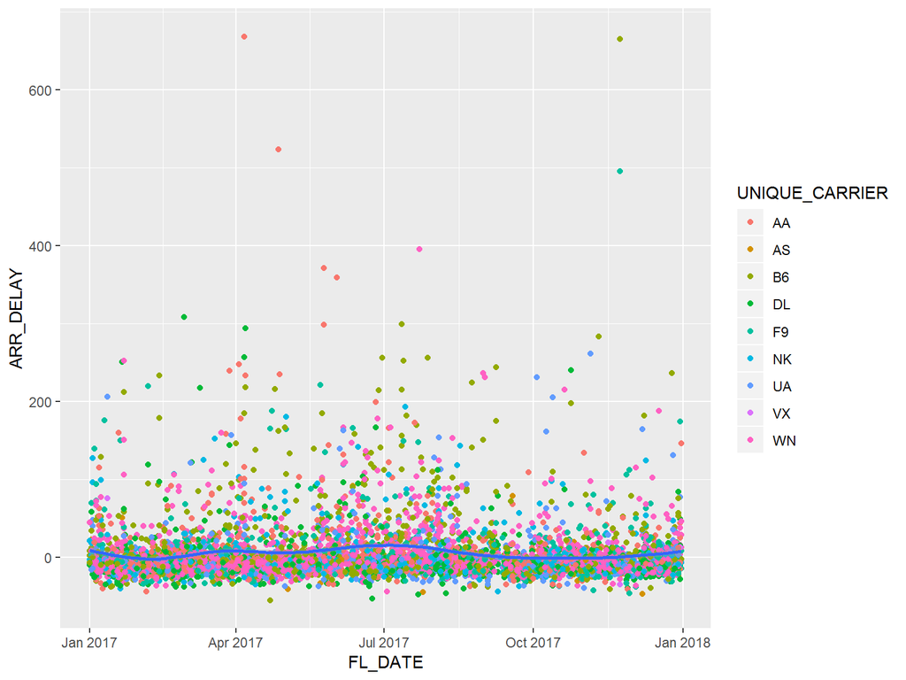

```r
ggplot(mydata, aes(x = FL_DATE, y = ARR_DELAY)) +
  geom_point(aes(color = UNIQUE_CARRIER)) +
  geom_smooth()
```

# Fancy Plotting - Dates vs. Arrival Delay

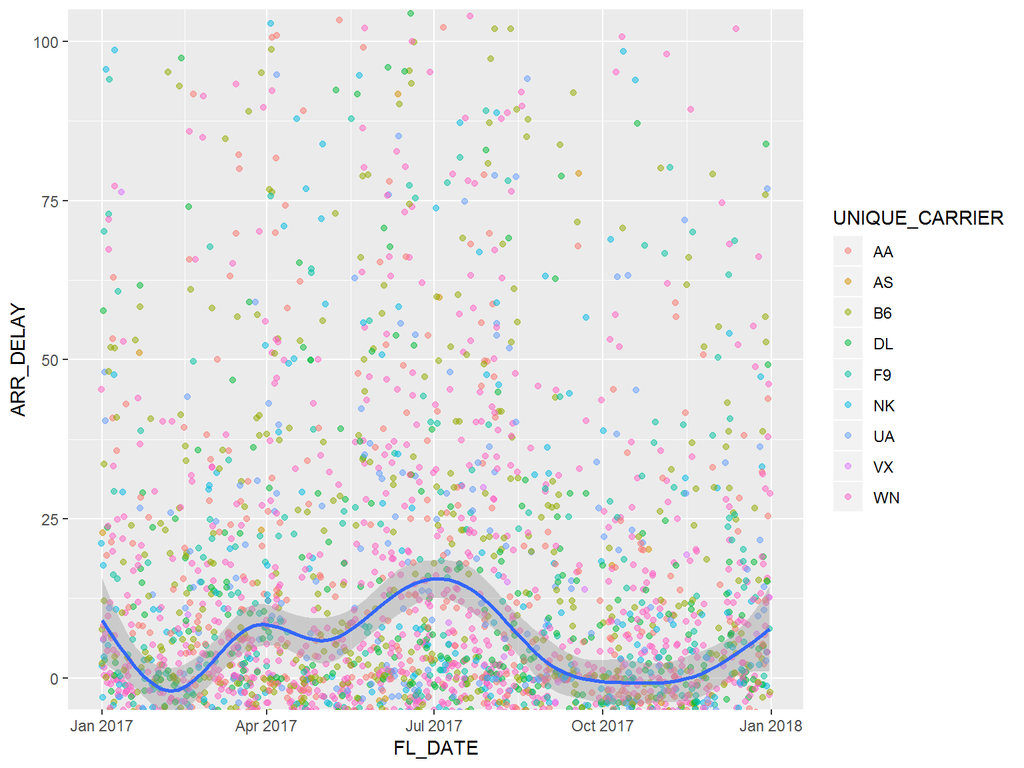

```r
ggplot(mydata, aes(x = FL_DATE, y =  ARR_DELAY)) +
  geom_jitter(alpha = .5, aes(color = UNIQUE_CARRIER)) +
  geom_smooth() +
  coord_cartesian(ylim = c(0,100))
```

# Fancy Plotting- Dates vs. Arrival Delay

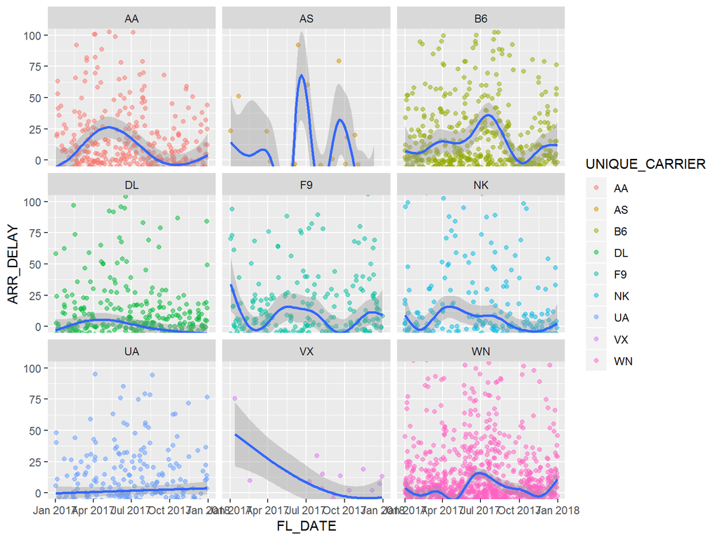

```r
ggplot(mydata, aes(x = FL_DATE, y =   ARR_DELAY)) +
  geom_jitter(alpha = .5, aes(color = UNIQUE_CARRIER)) +
  geom_smooth() +
  coord_cartesian(ylim = c(0,100)) +
  facet_wrap(~UNIQUE_CARRIER)
```

# Lots More Code Examples on Github

- https://github.com/crazybilly/airline-is470-class
  - clone the repo to your desktop and open airline-project.Rproj
- documentation in Rmd/html files
- code examples in R files